# Dragon element data analysis

Stephanie J. Spielman and Naman Srivastava

First, we create a dataset containing element network information joined with other attributes of elements. We specifically *only consider elements that are known to form at least five minerals on Earth since 4.33 Ga.* The following elements are therefore excluded (in parentheses is given the number of minerals it forms): Dy (1), Er (1), Gd (1), Hf (1), Sm (1), Re (2), Rb (3).

```
## # A tibble: 66 × 16
##    element n_elements n_minerals n_localities element_name element_hsab
##    <chr>        <dbl>      <dbl>        <dbl> <chr>        <chr>
##  1 Ag              28        172         3166 Silver       Soft acid
##  2 Al              52        881        10322 Aluminum     Hard acid
##  3 As              59        634         4664 Arsenic      Hard acid
##  4 Au              12         31         5616 Gold         Soft acid
##  5 B               42        232         1295 Boron        Soft acid
##  6 Ba              40        218         2904 Barium       Hard acid
##  7 Be              36        121         1352 Beryllium    Hard acid
##  8 Bi              40        212         1821 Bismuth      Int. acid
##  9 Br              15         13           88 Bromine      Soft base
## 10 C               50        417         9650 Carbon       Soft base
## # … with 56 more rows, and 10 more variables: atomic_mass <dbl>,
## #   number_of_protons <dbl>, element_table_period <dbl>,
## #   element_table_group <dbl>, atomic_radius <dbl>, pauling <dbl>,
## #   element_metal_type <chr>, element_density <dbl>,
## #   element_specific_heat <dbl>, element_crust_percent_weight <dbl>
```

### Analysis 1: What is the relationship between number of elements interacted with and number of minerals formed?

First, we explore whether we should likely transform an axis on a log-scale. Model diagnostics are shown below for the model with *log y and untransformed x*, whose diagnostics best meet assumptions.

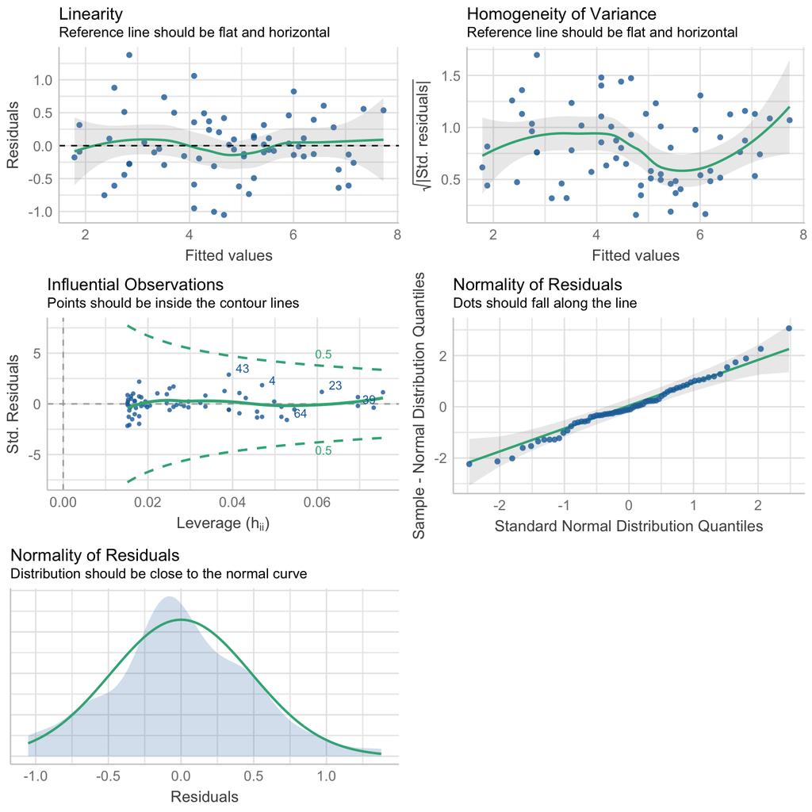

**The resulting model is as follows - *THERE IS A POSITIVE RELATIONSHIP.***

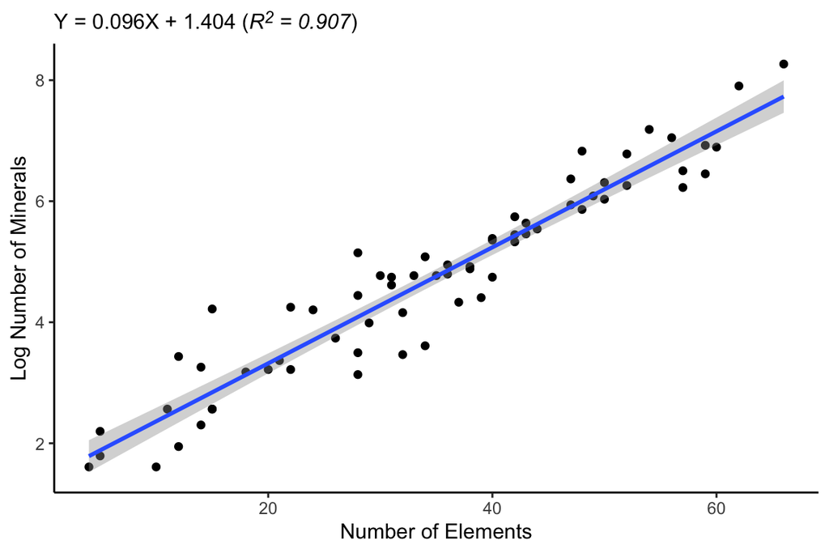

### Analysis 2: What is the relationship between number of elements interacted with and number of localities it is found at?

First, we explore whether we should likely transform an axis on a log-scale. Model diagnostics are shown below for the model with *log y and untransformed x*, whose diagnostics best meet assumptions.

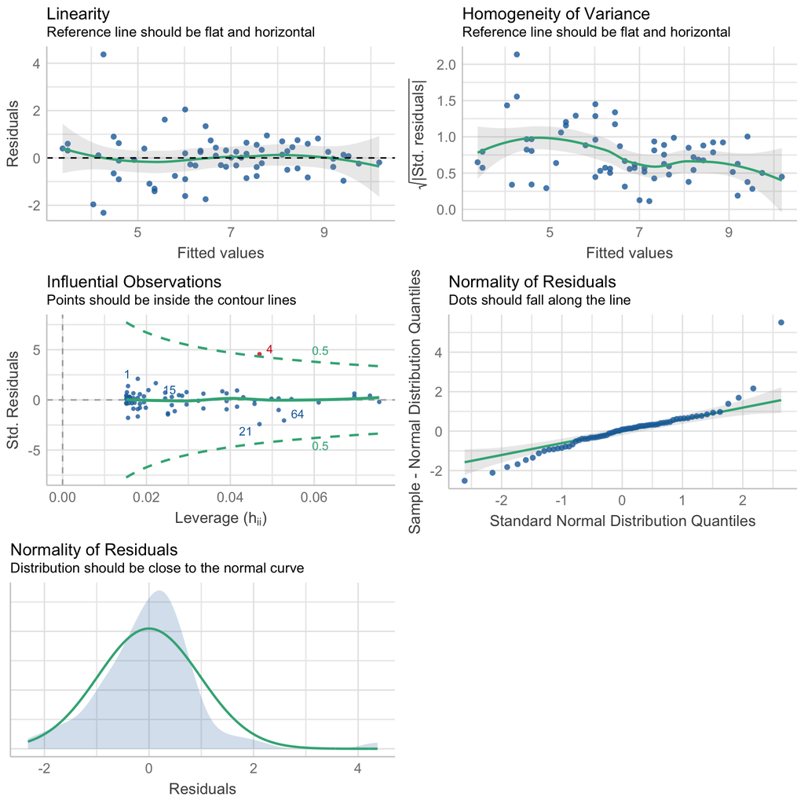

**The resulting model is as follows - *THERE IS A POSITIVE RELATIONSHIP.***

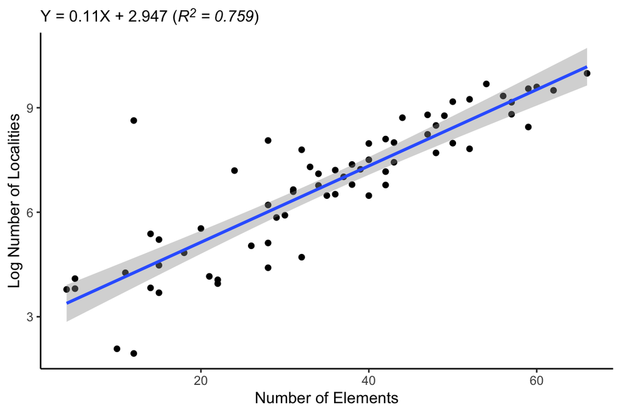

### Analysis 3: What is the relationship between number of elements interacted with and percentage of crust?

> Note that there are six elements which do not appear in this analysis because they are missing crust data - C, H, N, REE (rare earth elements), Rh, Te.

First, we explore whether we should likely transform an axis on a log-scale. Model diagnostics are shown below for the model with *log y and untransformed x*, whose diagnostics best meet assumptions.

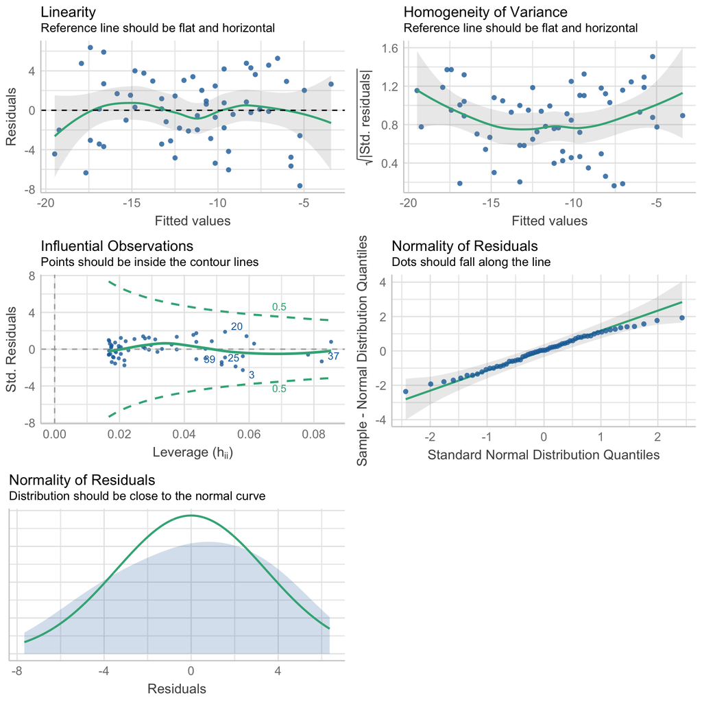

**The resulting model is as follows - *THERE IS A POSITIVE RELATIONSHIP.***

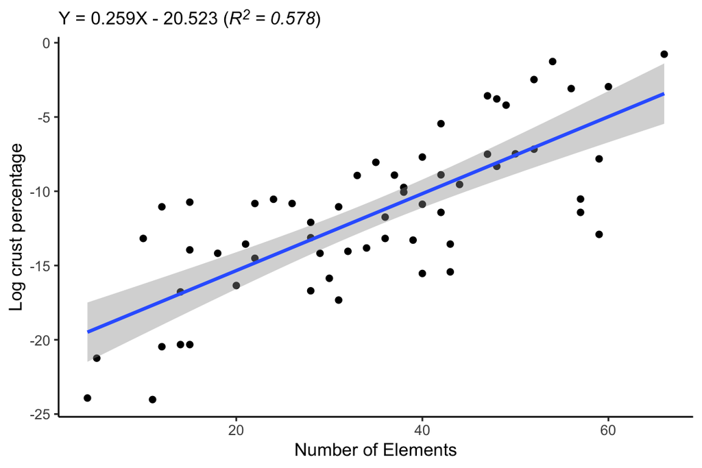

### Analysis 4: What is the relationship between number of elements interacted with and electronegativity?

First, we explore whether we should likely transform an axis on a log-scale. Model diagnostics are shown below for the model with *both untransformed y and x*, whose diagnostics best meet assumptions.

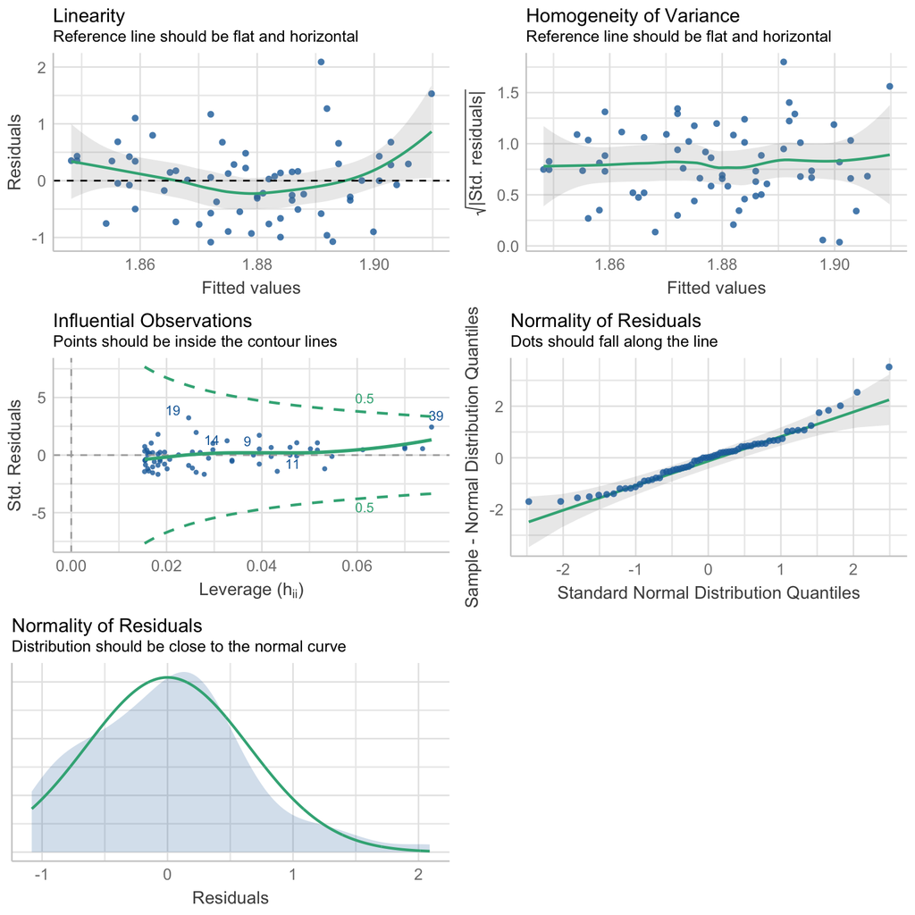

**The resulting model is as follows - *THERE IS NO RELATIONSHIP.*:**

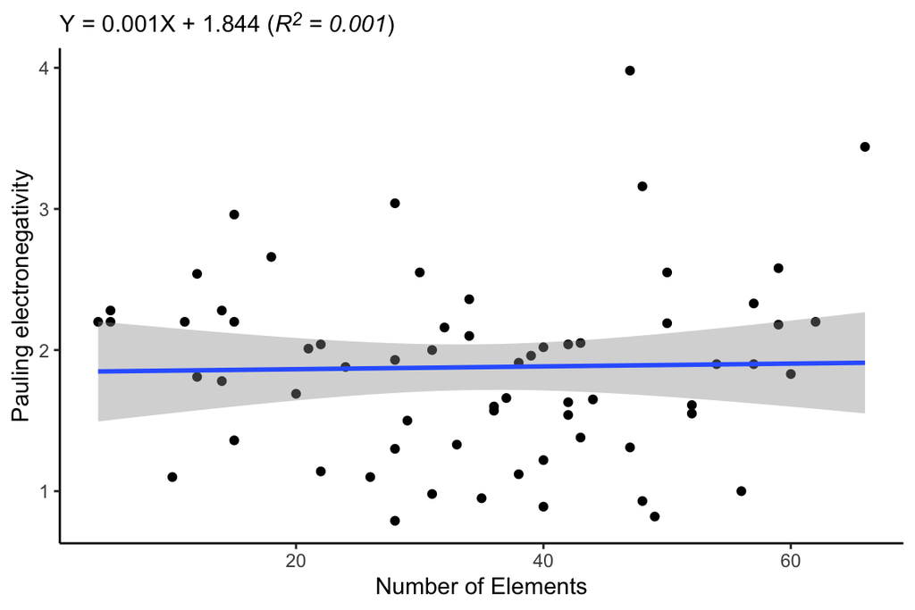

### Analysis 5: What is the relationship between number of minerals formed and electronegativity?

First, we explore whether we should likely transform an axis on a log-scale. Model diagnostics are shown below for the model with *log y and untransformed x*, whose diagnostics best meet assumptions.

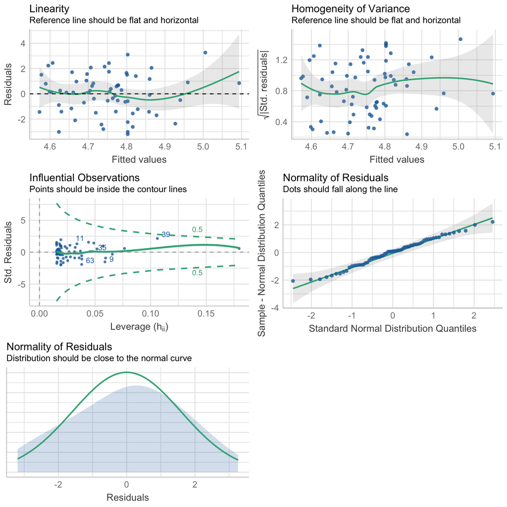

**The resulting model is as follows - *THERE IS NO RELATIONSHIP.***

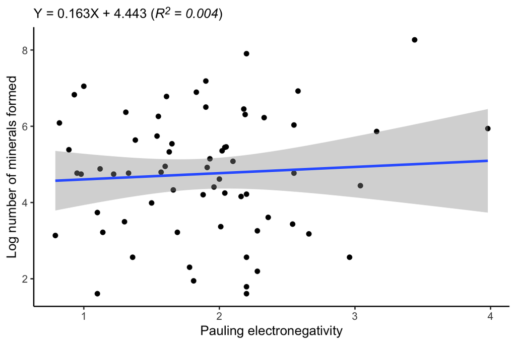